# Exercice_Metropolis_MCMC

Romain LACOSTE

03/12/2021

# Installing needed packages

```r
library("dplyr")
library("tidyverse")
```

# Question 1

## Mise en contexte

Le but de cette question est d’implémenter l’algorithme de Metropolis-Hastings sur R afin de simuler une variable aléatoire de densité suivante :
$$f(x) = e^{-|x|^{b}}, b \in \mathbb{R}$$
On dispose uniquement d’une loi uniforme, c’est-à-dire que l’on ne peut unqiquement simuler une variable aléatoire de loi uniforme :
$$Unif\{(-c, c)\}$$

Pour cela, on va voir f comme une loi cible à atteindre par méthode de Monte-Carlo par chaine de markov. A partir d’un noyau de transition Q donné, on va construire une chaine de markov ayant la loi cible comme loi stationnaire. La théorie ergodique permet de demontrer des résultats de convergence asymptotique et justifie ainsi cette démarche.

## Implémentation de l’algorithme

On crée ici une fonction nommé MCMCM dépendant de trois paramètres : - c : la taille du pas du noyau de transition Q - b : l’exposant dans la fonction cible à atteindre - n : le nombre d’itérations que l’algorithme va effectuer et qui renvoie la chaîne de markov constuite.

```r
MCMC <- function(b,c,n) {
  #On définit la loi cible a atteindre
  target <- function(x) {
    return(exp(-abs(x)^b))
    #return(0.5*dnorm(x,-2)+ 0.5*dnorm(x,2))
    }
  liste = rep(NA,n+1)
  #On choisit x0 la position initiale de la chaine de markov
  liste[1] = 2
  for (k in 2:(n+1)) {
    #On tire y = x + e avec e = Unif(-c,c)
    y = liste[k-1] + runif(1,-c,c)
    u = runif(1,0,1)
    alpha = min(1,target(y)/(target(liste[k-1])))
    #Acceptation ou rejet de la proposition
    if (u < alpha){
      liste[k] = y
    }
    else
      liste[k] = liste[k-1]
  }
  return(liste)
}
```

## Visualisation des résultats

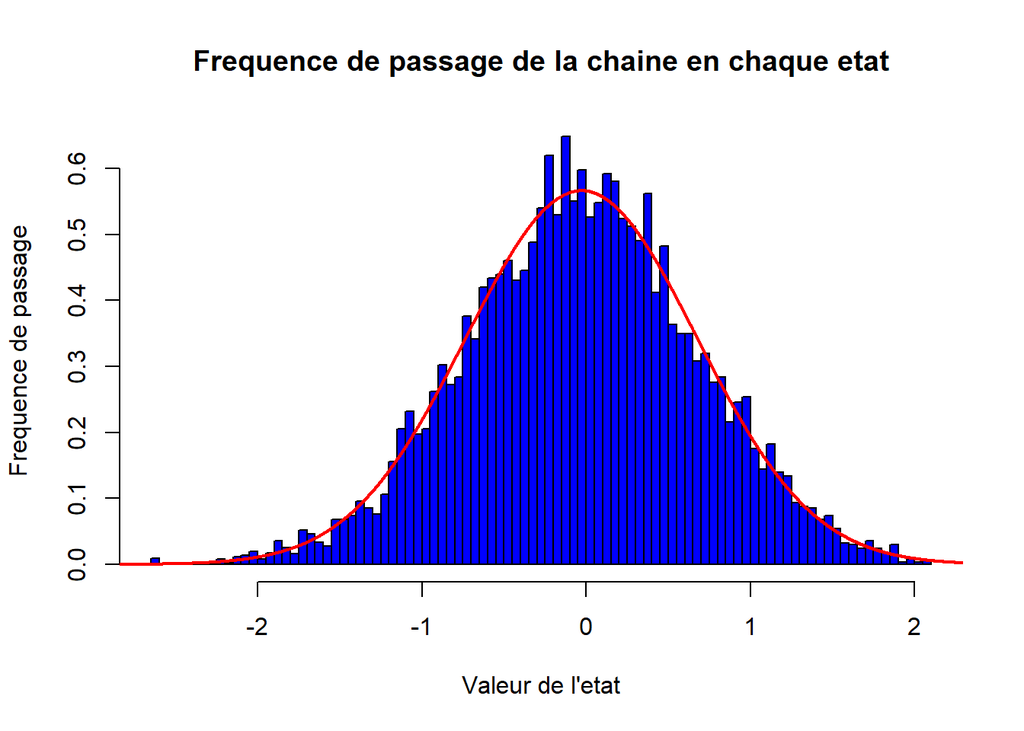

```r
#Valeur des parametres
n = 10000
b = 2
c = 1
abscisse = seq(from = -3, to = 3, length.out= n)
liste = MCMC(b,c,n)

#On trace l'histogramme de frequence de passage
hist(liste, breaks=100, col = "blue", main = "Frequence de passage de la chaine en chaque etat", xlab = "Valeur de l'etat", ylab = "Frequence de passage", freq = FALSE)
lines(abscisse,dnorm(abscisse,mean = mean(liste), sd = var(liste)^0.5), type = "l", xlab = "x", ylab = "f(x)", main= "Loi cible f a atteindre", col = "red", lwd = 2)
```

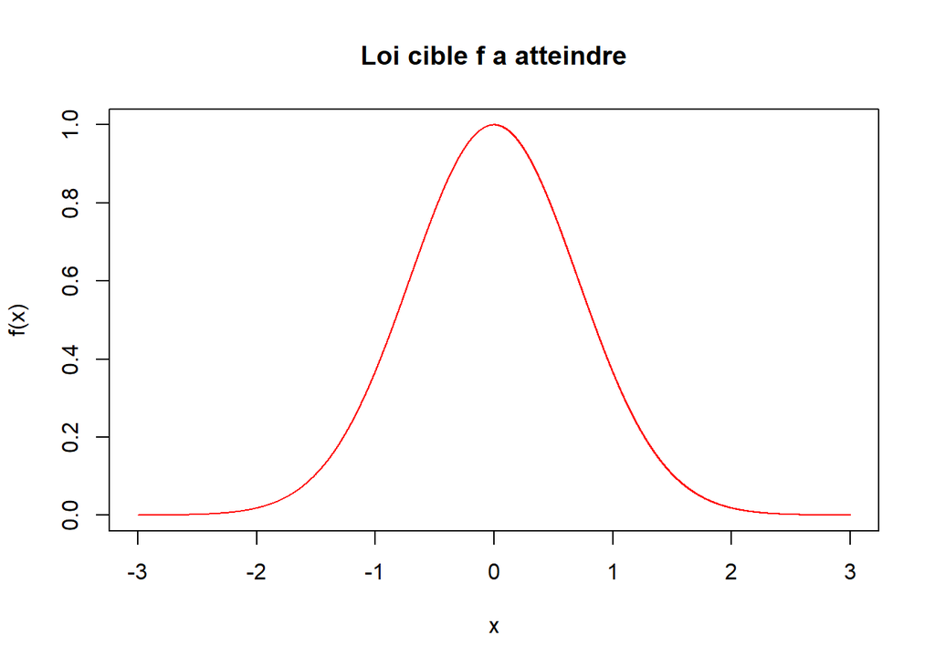

```r
#On trace la loi cible a atteindre
plot(abscisse,exp(-abs(abscisse)^b), type = "l", xlab = "x", ylab = "f(x)", main= "Loi cible f a atteindre", col = "red")
```

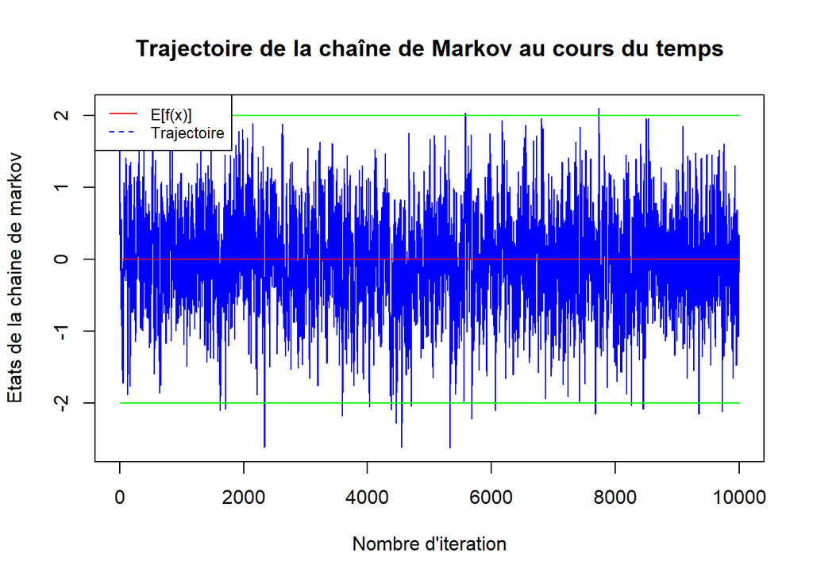

```r
#On trace la trajectoire de la chaîne de Markov
plot(seq(from = 0, to = n), liste, type = "l", xlab = "Nombre d'iteration", ylab = "Etats de la chaine de markov", main = "Trajectoire de la chaîne de Markov au cours du temps", col = "blue")
lines(seq(from = 0, to = n-1), 0*seq(from = 0, to = n-1), col = "red")
lines(seq(from = 0, to = n-1), 2+ 0*seq(from = 0, to = n-1), col = "green")
lines(seq(from = 0, to = n-1), -2+ 0*seq(from = 0, to = n-1), col = "green")
legend("topleft", legend=c("E[f(x)]", "Trajectoire"),
       col=c("red", "blue"),lty = 1:2, cex=0.8)
```

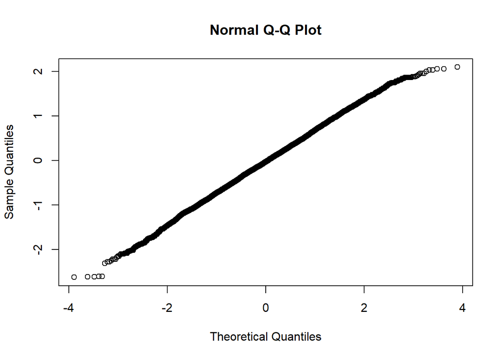

```r
qqnorm(liste)
```

# Question 2

## Mise en contexte

L’algorithme de Metropolis-Hasting crée une chaîne de Markov (Xn) qui a comme loi stationaire la loi cible à atteindre. D’après le théorème Ergodique, pour g une fonction mesurable sur l’ensemble des états de la chaîne de Markov et intégrale, on a :
$$\frac{1}{n}\sum_{k=0}^n g(X_{k}) \underset{n\to +\infty}{\longrightarrow} \mathbb{E}_{f}(g(X))$$
Ainsi puisque la loi cible est centrée et en prenant g(x) = x^2 on obtient :
$$\frac{1}{n}\sum_{k=0}^n V(X_{k}) \underset{n\to +\infty}{\longrightarrow} V(X)$$
D’ou l’estimateur de la variance de la loi cible est donné :
$$\hat{I}_{n} = \frac{1}{n}\sum_{k=0}^n g(X_{k})$$
et d’après ce qui précède on a bien :
$$\hat{I}_{n} \underset{n\to +\infty}{\longrightarrow} V(X)$$

## Estimatation de la variance de la loi cible

```r
#Estimateur de la variance de la loi cible
n = 40
I = sum(MCMC(2,5,n)^2)/n
print(I)
```

```
## [1] 1.211317
```

```r
#On calcule la variance de l'estimateur I
var_estimateur <- function(b,c,n,M){
   rerun(M,sum(MCMC(b,c,n)^2)/n)%>%unlist%>%(var)
}

print(var_estimateur(2,15,n,25))
```

```
## [1] 0.9984664
```

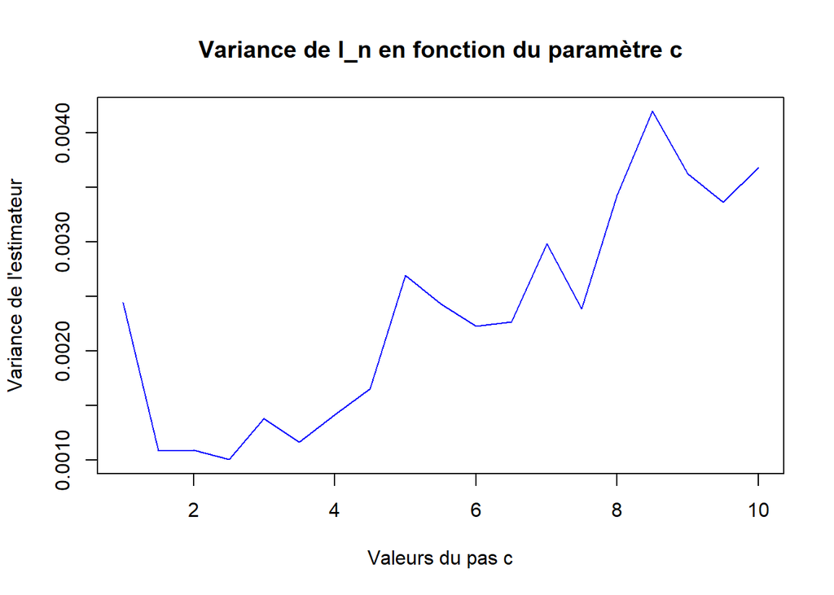

```r
c_liste = seq(1,10,0.5)
Ik_liste = map_dbl(c_liste, var_estimateur, b=2, n=2000, M=100)

plot(c_liste, Ik_liste, col="blue", type = "l", xlab = "Valeurs du pas c", ylab = "Variance de l'estimateur", main= "Variance de I_n en fonction du paramètre c")
```